# df

Autogenerated data summary from dataMaid

2021-09-13 03:21:17

# Data report overview

The dataset examined has the following dimensions:

| Feature | Result |
| --- | --- |
| Number of observations | 569 |
| Number of variables | 6 |

### Checks performed

The following variable checks were performed, depending on the data type of each variable:

|  | character | factor | labelled | haven labelled | numeric | integer | logical | Date |
| --- | --- | --- | --- | --- | --- | --- | --- | --- |
| Identify miscoded missing values | × | × | × | × | × | × |  | × |
| Identify prefixed and suffixed whitespace | × | × | × | × |  |  |  |  |
| Identify levels with < 6 obs. | × | × | × | × |  |  |  |  |
| Identify case issues | × | × | × | × |  |  |  |  |
| Identify misclassified numeric or integer variables | × | × | × | × |  |  |  |  |
| Identify outliers |  |  |  |  | × | × |  | × |

Please note that all numerical values in the following have been rounded to 2 decimals.

# Summary table

|  | Variable class | # unique values | Missing observations | Any problems? |
| --- | --- | --- | --- | --- |
| mean_radius | numeric | 456 | 0.00 % | × |
| mean_texture | numeric | 479 | 0.00 % | × |
| mean_perimeter | numeric | 522 | 0.00 % | × |
| mean_area | numeric | 539 | 0.00 % | × |
| mean_smoothness | numeric | 474 | 0.00 % | × |
| diagnosis | integer | 2 | 0.00 % |  |

# Variable list

## mean_radius

| Feature | Result |
| --- | --- |
| Variable type | numeric |
| Number of missing obs. | 0 (0 %) |
| Number of unique values | 456 |
| Median | 13.37 |
| 1st and 3rd quartiles | 11.7; 15.78 |
| Min. and max. | 6.98; 28.11 |

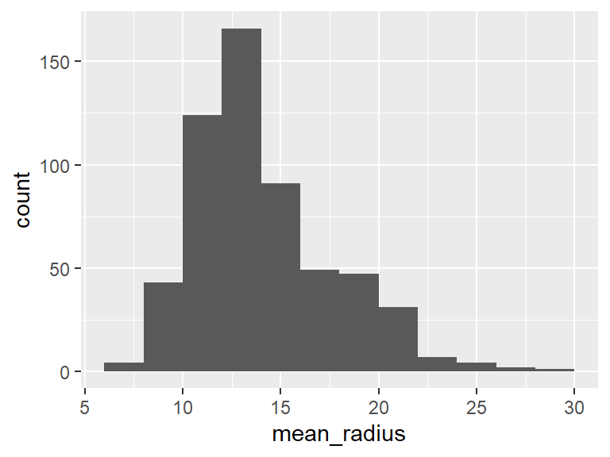

- Note that the following possible outlier values were detected: "6.98", "7.69", "7.73", "7.76", "8.2", "8.22", "8.57", "8.6", "8.6", "8.62" (12 additional values omitted).

## mean_texture

| Feature | Result |
| --- | --- |
| Variable type | numeric |
| Number of missing obs. | 0 (0 %) |
| Number of unique values | 479 |
| Median | 18.84 |
| 1st and 3rd quartiles | 16.17; 21.8 |
| Min. and max. | 9.71; 39.28 |

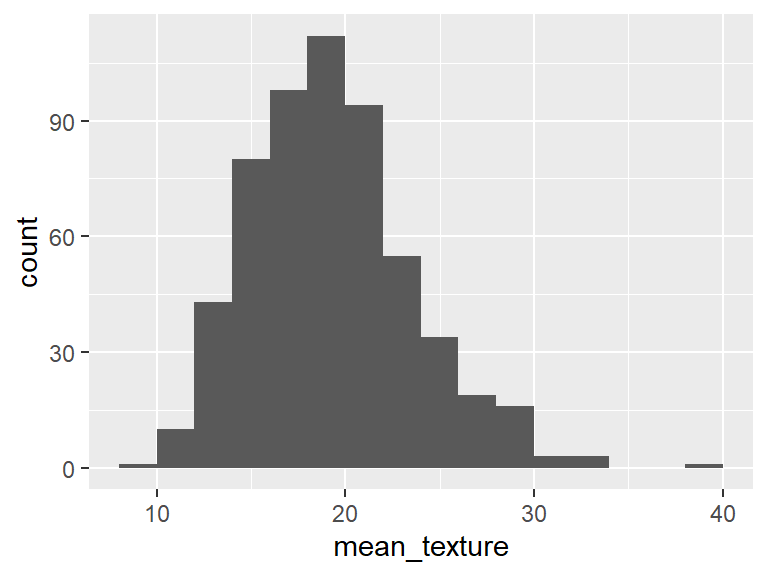

- Note that the following possible outlier values were detected: "9.71", "10.38", "33.56", "33.81", "39.28".

## mean_perimeter

| Feature | Result |
| --- | --- |
| Variable type | numeric |
| Number of missing obs. | 0 (0 %) |
| Number of unique values | 522 |
| Median | 86.24 |
| 1st and 3rd quartiles | 75.17; 104.1 |
| Min. and max. | 43.79; 188.5 |

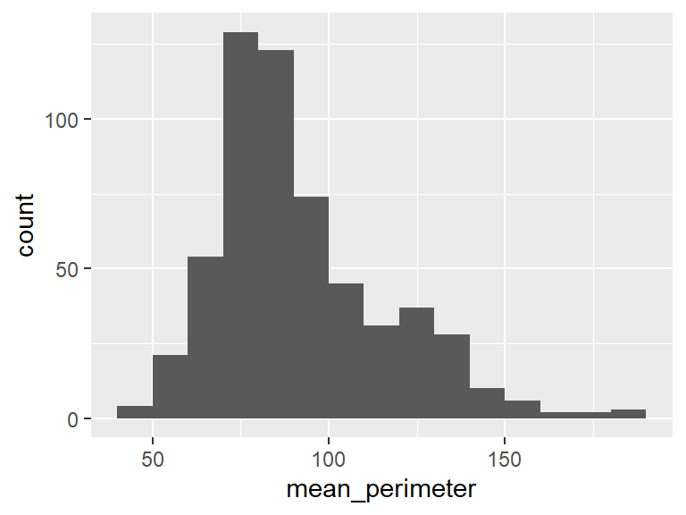

- Note that the following possible outlier values were detected: "43.79", "47.92", "47.98", "48.34", "51.71", "53.27", "54.09", "54.34", "54.42", "54.53" (18 additional values omitted).

## mean_area

| Feature | Result |
| --- | --- |
| Variable type | numeric |
| Number of missing obs. | 0 (0 %) |
| Number of unique values | 539 |
| Median | 551.1 |
| 1st and 3rd quartiles | 420.3; 782.7 |
| Min. and max. | 143.5; 2501 |

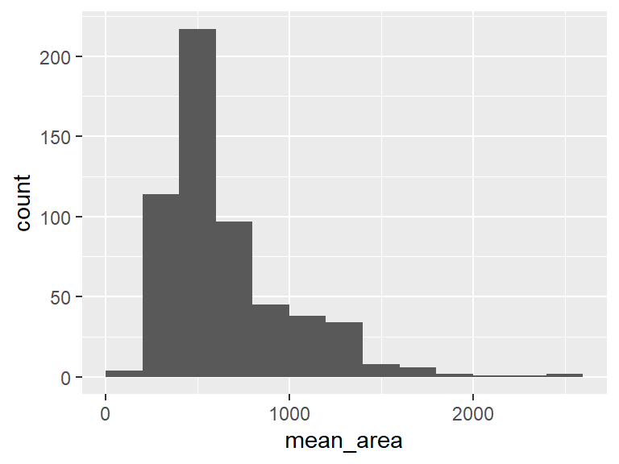

- Note that the following possible outlier values were detected: "143.5", "170.4", "178.8", "181", "201.9", "203.9", "221.2", "221.3", "221.8", "224.5" (21 additional values omitted).

## mean_smoothness

| Feature | Result |
| --- | --- |
| Variable type | numeric |
| Number of missing obs. | 0 (0 %) |
| Number of unique values | 474 |
| Median | 0.1 |
| 1st and 3rd quartiles | 0.09; 0.11 |
| Min. and max. | 0.05; 0.16 |

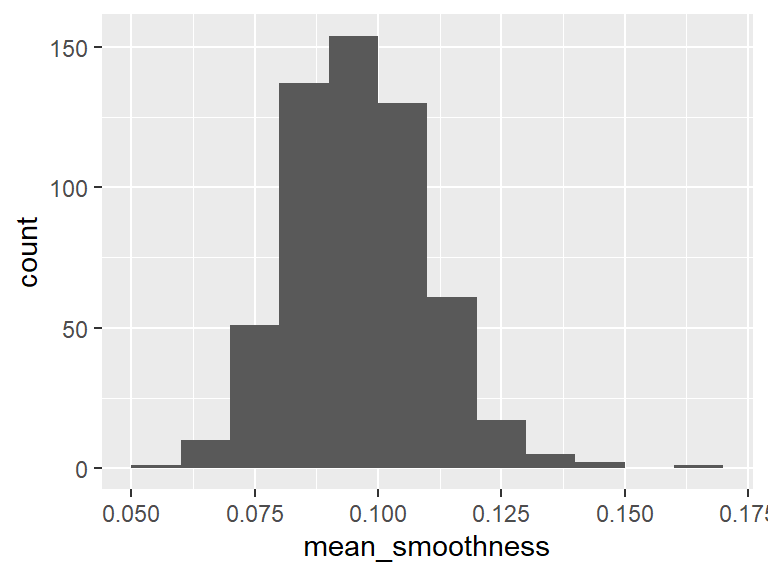

- Note that the following possible outlier values were detected: "0.05", "0.14", "0.14", "0.14", "0.14", "0.16".

## diagnosis

- Note that this variable is treated as a factor variable below, as it only takes a few unique values.

| Feature | Result |
| --- | --- |
| Variable type | integer |
| Number of missing obs. | 0 (0 %) |
| Number of unique values | 2 |
| Mode | “1” |
| Reference category | 0 |

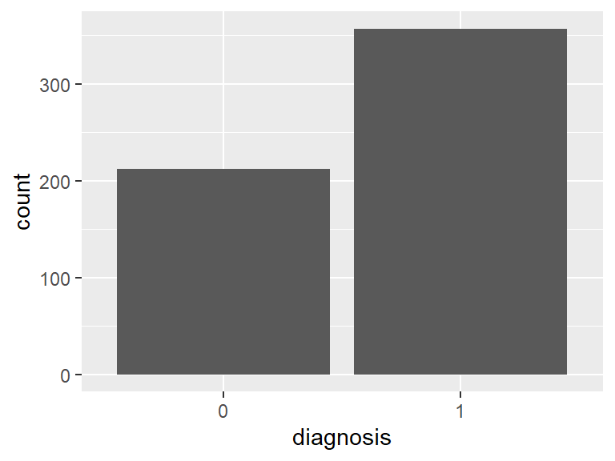

Report generation information:

- Created by: christopherohit (username: `Hendrich`).
- Report creation time: Mon Sep 13 2021 03:21:19
- Report was run from directory: `C:/Users/Hendrich/Desktop/BTL_Software_Technology/Analysis_Problem_By_R`
- dataMaid v1.4.0 [Pkg: 2019-12-10 from CRAN (R 4.0.5)]
- R version 4.0.5 (2021-03-31).
- Platform: x86_64-w64-mingw32/x64 (64-bit)(Windows 10 x64 (build 19042)).
- Function call: `makeDataReport(data = df, render = FALSE, file = "EDA.Rmd", replace = TRUE)`